# Who cut, who sold?

What happened to the tree canopy on TRG’s Commercial Forest land, Houghton & Keweenaw Counties

Randy Swaty

Julia Petersen

2026-10-26

## The short answer

- In 2020, **TRG** owned most of the big-company forest land here. By 2026 it had sold nearly all of it to **Verdant** (a different company). Verdant then sold part of that land to **The Nature Conservancy** (the Keweenaw Heartlands) and, in 2026, another part to **American Songbird**.
- **TRG → Verdant:** canopy slipped from 74.9% to 73.4%; 6.5% of the acres were heavily cut.
- **TRG → Verdant → Heartlands:** clearing peaked in 2020–21, then **stopped**. Canopy recovered to 75.5%, and **no** acres were heavily cut.
- **TRG → Verdant → Songbird:** the **heaviest cutting**. 20.2% of the acres were heavily cut, mostly in 2024–25, just before the sale.
- Two independent satellite records, USFS canopy cover and Hansen forest loss, put these drops in the **same places and years**.
- Overall, big-company land was heavily cut about **11 times as often** as other private land, measured in acres.

## The setting

- Michigan’s **Commercial Forest Program (CFP)**: owners get a property-tax break for keeping land in forest and open to public hunting and fishing.
- The state lists every enrolled parcel and its owner. We used the **2020** and **2026** lists.
- Much of this land is owned by **institutional owners**: investment companies that own forests for pension funds and other investors (here: TRG, Verdant, Molpus, Lyme).

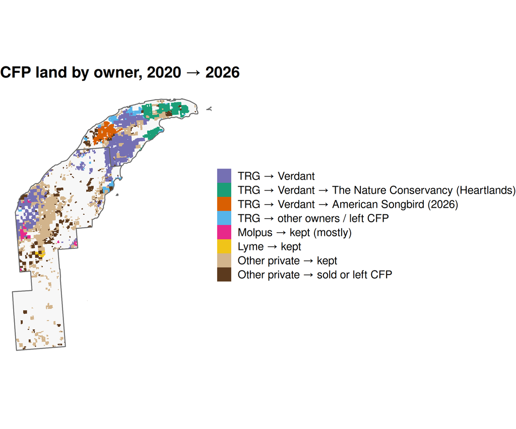

## The questions

1. Where did **TRG’s** 2020 forest land go by 2026?
2. How did tree canopy change on land that went **TRG → Verdant**, compared with land that went **TRG → Verdant → The Nature Conservancy** (Heartlands)?
3. Where does the 2026 **American Songbird** purchase from Verdant fit?
4. **Where and when** did the canopy drop inside the Heartlands and Songbird boundaries, and do two satellite records agree?
5. Do big companies treat their land differently from **other private owners**?

## What we measured

| Information | What it tells us |
| --- | --- |
| State CFP owner lists, 2020 and 2026 | Who owned each parcel at each date |
| USFS Tree Canopy Cover, every year 2010–2025 | Share of the ground covered by treetops, for every 30 × 30 m cell |
| Hansen Global Forest Change, through 2024 | The year an area’s trees were **cleared** (heavy clearing only) |
| LANDFIRE Annual Disturbance, 2010–2025 | Where and when the forest was disturbed each year, and its cause where known |
| Maps of the Songbird and Heartlands sale boundaries | Which land changed hands in those two sales, including the 2026 Songbird sale that the state list doesn’t show yet |

A drop from 75% to 65% canopy is a **10-point** drop.

## How we defined things

- **TRG and Verdant are different companies.** TRG in 2020 and Verdant in 2026 counts as **sold**. The Heartlands land went TRG → Verdant (2022) → The Nature Conservancy (2022–23).
- **Other private owners:** everyone except the four investment companies: individuals and families, but also other timber companies (Lake Superior Timberlands holds 55% of the “kept” acres). **Kept** = same owner in 2020 and 2026; **sold** = new owner or left the program.
- **Heavy cutting:** a parcel’s average canopy fell by **more than 20 points**, 2020 → 2025. This is our yardstick, not an official standard.
- **Year the canopy dropped** (maps): the first year a 30 m cell’s canopy fell **15 points or more** below its highest value in the previous 3 years.
- **Important catch:** the 2026 state list still shows the Songbird land as Verdant’s, because the sale happened after the list was made. The sale boundary maps fixed this.
- **Two ways of measuring:**
  - **By parcel:** each parcel’s average canopy change, used to count heavily cut acres.
  - **By satellite cell:** the canopy data come as a grid of 30 × 30 m cells (about ¼ acre each). The by-year charts average every cell in each group’s land.

## Where TRG’s land went

| 2020 → 2026 | Parcels | Acres | Canopy 2020 | Canopy 2025 | Acres heavily cut |
| --- | --- | --- | --- | --- | --- |
| TRG → Verdant | 497 | 105,901 | 74.9% | 73.4% | 6,837 (6.5%) |
| TRG → Verdant → The Nature Conservancy (Heartlands) | 152 | 30,973 | 70.5% | 75.5% | 0 (0.0%) |
| TRG → Verdant → American Songbird (2026) | 91 | 15,350 | 72.8% | 64.8% | 3,097 (20.2%) |
| TRG → other owners / left CFP | 98 | 12,600 | 70.9% | 74.2% | 46 (0.4%) |

- Of the 12,219 acres heavily cut across all enrolled land, **82%** were on land TRG owned in 2020.
- Most of TRG’s land went to **Verdant**, so the TRG → Verdant group is the largest by far.
- Of the “other owners / left CFP” row, 10,819 acres went to about 10 other owners and are **still enrolled**; only 1,781 acres left the program.

## Share of acres heavily cut

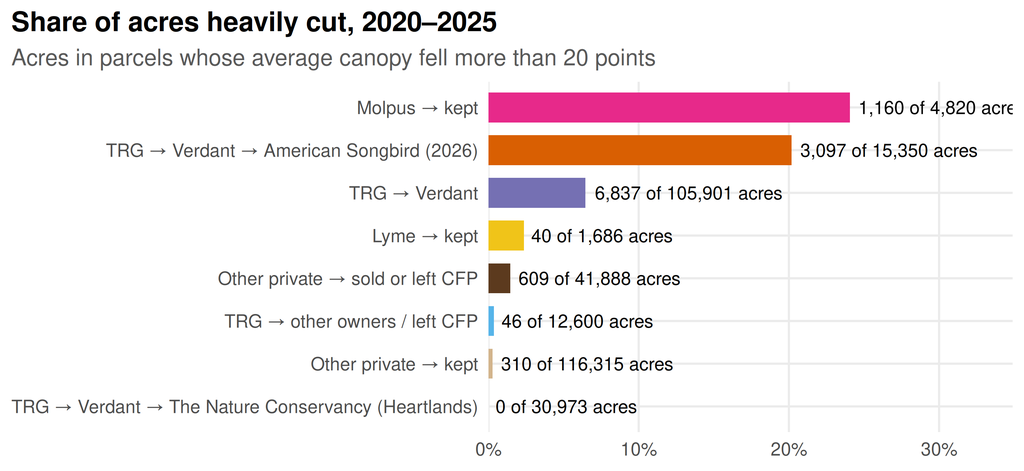

Among TRG’s former land, the buyer made the difference: **20.2%** of the Songbird acres were heavily cut, compared with 6.5% of the rest of Verdant’s acres and **0.0%** of the Heartlands acres.

## Canopy cover by year

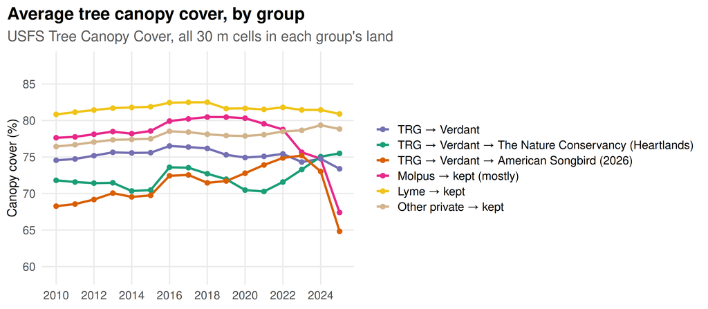

**TRG → Verdant** drifted down from 76.2% (2018) to 73.4%. **Heartlands** rose from 70.3% (2021) to **75.5%**. **Songbird** fell from 75.2% (2023) to **64.8%**. **Molpus** (kept) slid from 80.3% (2020) to 74.8%, then fell to **67.4%** in 2025.

## Forest clearing by year

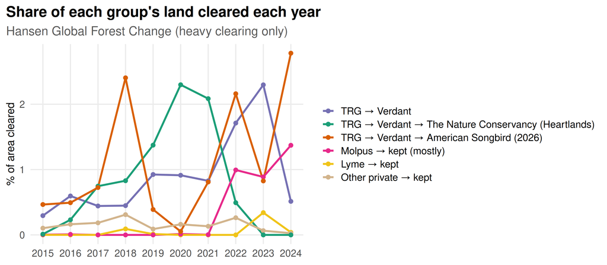

**TRG → Verdant** clearing peaked in 2023 (2.3%). **Heartlands** peaked in 2020–21 and was **near zero by 2023–24**. **Songbird** rose in 2022 and again in **2024 (2.8%)**.

## LANDFIRE disturbance by year

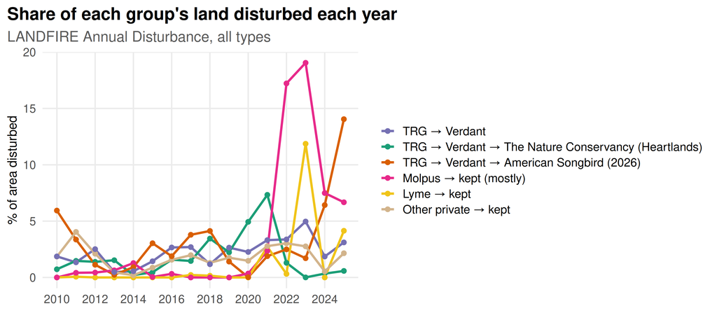

**Songbird** reached **14.0%** in 2025, the highest of any group that year. **Heartlands** has been near zero since 2023. On TRG’s former land, LANDFIRE labels none of the disturbance as harvest and 94% as “unknown” (the rest is insects or disease), so it can’t tell us the cause.

## Heartlands Acres: Canopy Cover Loss, 2012–2022

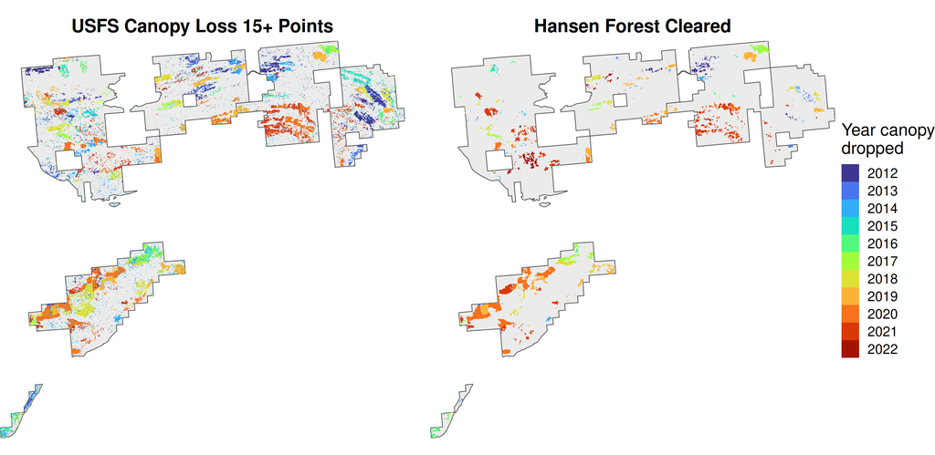

Before The Nature Conservancy bought it, drops clustered in **2018–2021** (orange and red), in the southern block and the east of the northern blocks. The canopy record (left) flags 7,434 acres; Hansen (right) flags 2,773 acres.

How a cell gets coloured: **left**, the first year its canopy fell 15+ points below its highest value in the previous 3 years; **right**, the year Hansen detected stand-replacing loss (trees across the whole 30 m cell cleared). Hansen is yes/no, with no partial-loss scale.

## Songbird Acres: Canopy Cover Loss, 2015–2025

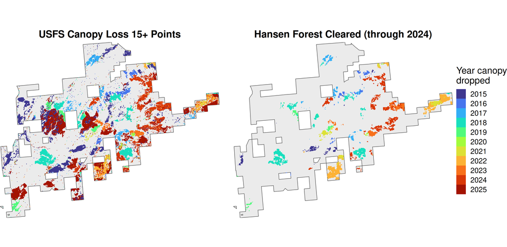

The largest drops are recent (dark red, **2024–2025**), in the west-centre and the east. The canopy record flags 5,393 acres; Hansen flags 1,734 acres (its record ends in 2024).

How a cell gets coloured: **left**, the first year its canopy fell 15+ points below its highest value in the previous 3 years; **right**, the year Hansen detected stand-replacing loss (trees across the whole 30 m cell cleared). Hansen is yes/no, with no partial-loss scale.

## Do the two records agree?

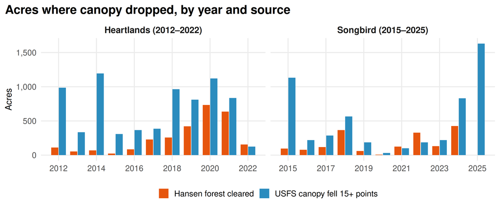

- **Where Hansen sees clearing, the canopy record almost always agrees:** 83% (Heartlands) and 88% (Songbird) of Hansen’s acres, within a year of each other 90–94% of the time.
- The canopy record flags about **3 times as many acres**: likely lighter cuts that Hansen misses, plus some noise (for example, the canopy-record spikes in 2014 for Heartlands and 2015 for Songbird, when Hansen saw little clearing).

## Map: canopy change, 2020 → 2025

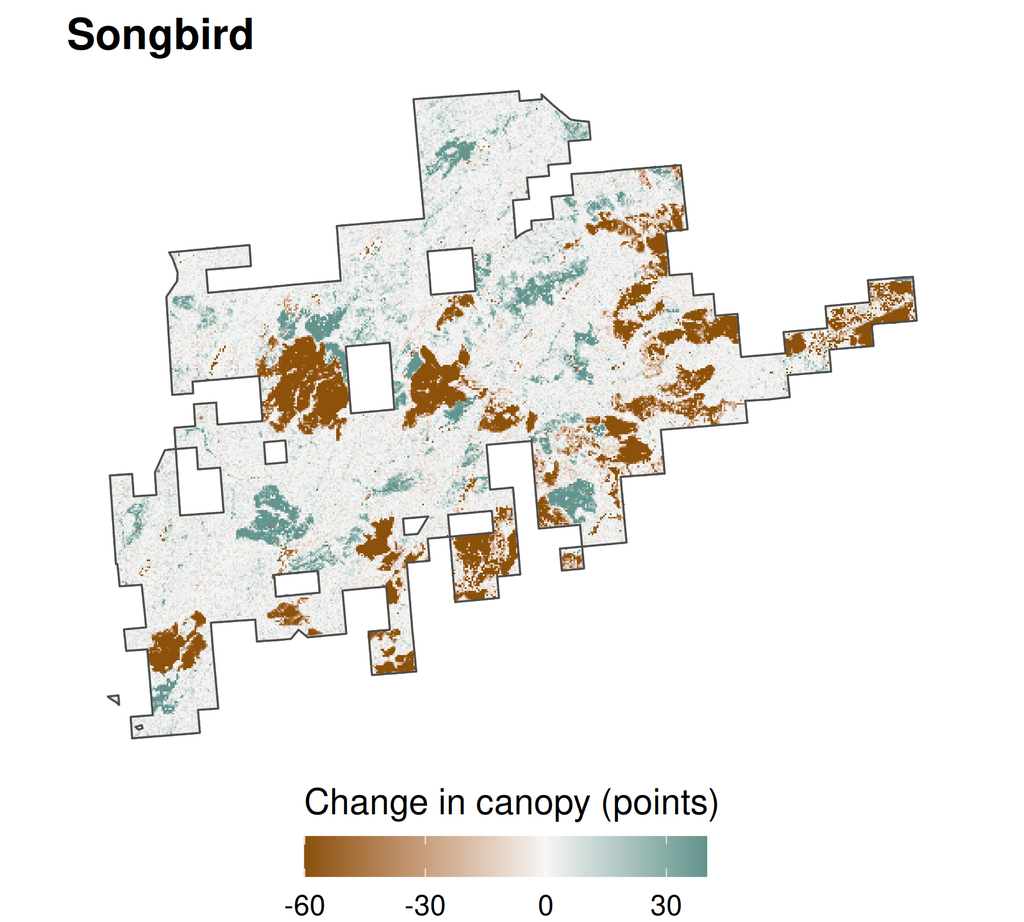

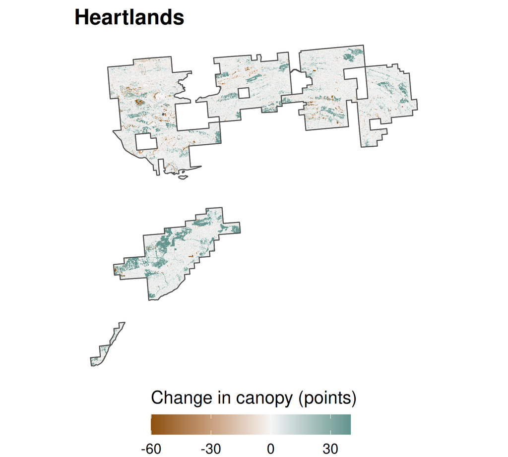

Brown = canopy lost, green = canopy gained. Songbird shows large blocks of loss; Heartlands is mostly regrowth.

## Owner by owner

- **TRG:** sold nearly all of its 164,825 enrolled acres between 2020 and 2026 (see “Where TRG’s land went”).
- **Verdant:** bought most of TRG’s land, cut moderately, and sold part of it to American Songbird in 2026.
- **Molpus** (listed as “MWF,” for Molpus Woodlands Fund):
  - **Vulcan** parcels (kept): canopy fell an average of **14.4 points**; 3 of 14 parcels heavily cut.
  - **Ned Lake** parcels: mostly stable.
- **Lyme:** kept all its land, with little cutting (1 of 28 parcels).
- **Manulife:** no enrolled land in these two counties.

## Big companies vs. other private owners

|  | Acres | Acres heavily cut | Share |
| --- | --- | --- | --- |
| Institutional owners | 171,890 | 11,300 | **6.6%** |
| Other private owners | 158,203 | 920 | **0.6%** |

All 2020 enrolled land, sold or not. Big-company land was heavily cut about **11 times as often** as other private land.

## The bigger picture: all land in both counties

- So far we’ve looked at Commercial Forest land. This section covers **all 860,741 acres** of land in Houghton and Keweenaw counties (mainland, open water excluded).
- **Biophysical Settings (BpS):** the vegetation the land would naturally support, under its historical disturbance regime (LANDFIRE 2020).
- **Existing Vegetation Type (EVT):** what’s growing there now (LANDFIRE 2024).
- **Historical disturbance:** how much land the BpS models expect to be disturbed each year by fire, wind, insects and other natural causes.
- **Current disturbance:** what LANDFIRE’s annual maps recorded, 2010–2025.

## What the land would naturally support

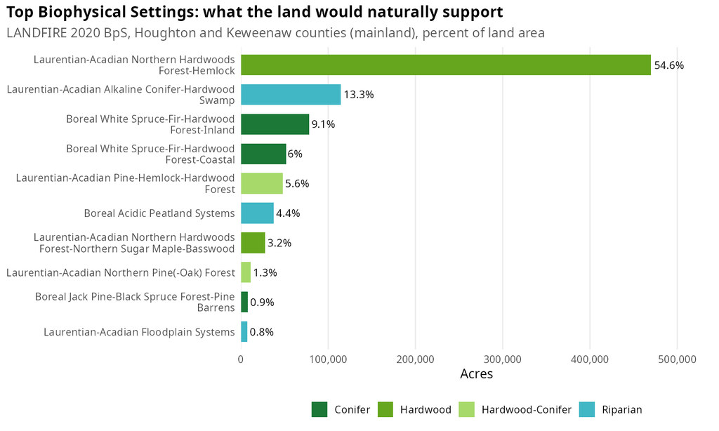

Northern hardwoods with hemlock cover **54.6%** of the land. Swamps, spruce-fir and pine-hemlock-hardwood make up most of the rest.

## What’s there now

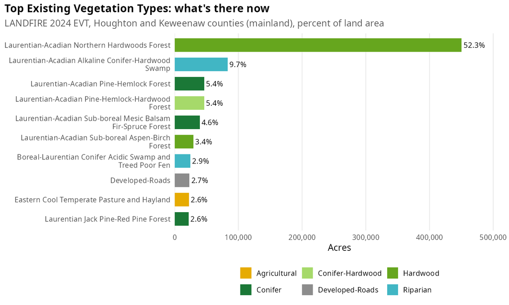

Northern hardwoods still dominate (**52.3%**). Spruce-fir is much less common than its BpS share, and aspen-birch (3.4%) is the young forest that grows back after cutting.

## Disturbance per year: historical vs. now

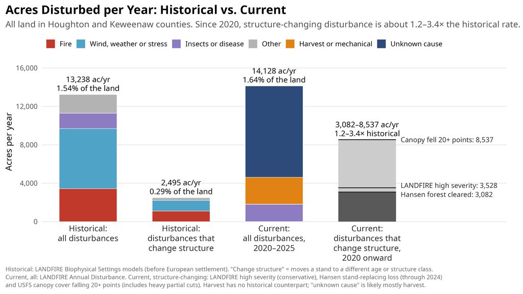

Historically, disturbances that changed forest structure hit about **2,495 acres a year** (0.3% of the land). Many more were light, like windthrow that leaves an old forest old; counting those gives 13,238 acres a year.

## Disturbance by year vs. the historical expectation

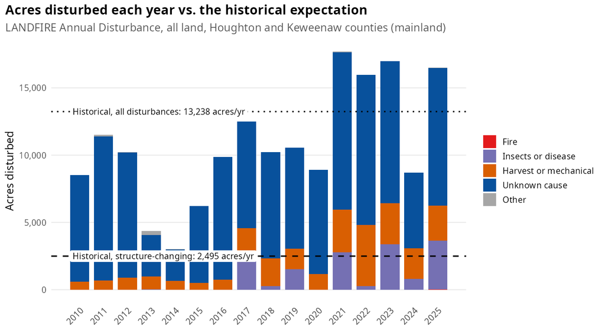

## Takeaways

**Plain version:** one big timber company, TRG, sold almost all of its land. The land that went to The Nature Conservancy has been growing back. The land that went to Verdant was cut moderately, and the part Verdant sold to American Songbird in 2026 was cut hard in the two years before that sale.

**Technical version:** treating TRG → Verdant as a sale, the signal depends on the destination. Songbird land shows a sharp canopy decline in 2024–25, before the 2026 sale. Heartlands/TNC land shows clearing stopping after 2021 and steady regrowth. Hansen, Tree Canopy Cover and LANDFIRE agree on where and when, but LANDFIRE can’t name a cause on private CFP land.

## Appendix: sources and scripts

- **CFP parcels:** Michigan DNR, 2020 and 2026 (`inputs/cfp/`)
- **Tree Canopy Cover:** USFS, annual 2010–2025, 30 m
- **Forest clearing:** Hansen Global Forest Change, loss year through 2024
- **Disturbance:** LANDFIRE Final Annual Disturbance, 2010–2025 (`inputs/landfire/annual_disturbance/`)
- **Sale boundaries:** American Songbird (from Emma) and Keweenaw Heartlands
- **Scripts:**
  - `09_cfp_parcel_tcc_change.R`, `10_institutional_sellers_vs_keepers.R`: parcel canopy change and ownership groups
  - `11_sale_footprint_pixels.R`, `12_sale_footprint_landfire_tcc.R`: group areas, clearing and canopy by year
  - `15_get_landfire_annual_dist.py`, `16_landfire_annual_dist.R`: LANDFIRE annual disturbance
  - `17_footprint_drop_year_maps.R`: year-the-canopy-dropped maps and source agreement
  - `18_bps_evt_disturbance_regimes.R`: BpS, EVT, and historical vs. current disturbance (LANDFIRE 2020 BpS, 2024 EVT, BpS model tables)